# Individualised and dynamic representations of text data

Bennett Kleinberg

14 February, 2021

## Text as data!?

*Text is everywhere. And everything is text.*

- the past decade in AI research was dominated by advances Natural Language Processing (NLP)
- paradigm shift in NLP: fully statistical approach to language tapping into semantics [1–3]
- promise: “text as data” as a new lens on human behaviour [4–6]

Cross-disciplinary conundrum: **untapped potential** for social sciences and **missed opportunities** for NLP

## Unlocking the potential

Goal: narrowing the gap in our fundamental understanding of text data for social science research

Objectives:

1. advancing the methods from statistical NLP to individual-level and longitudinal data
2. understanding how changes in language representation correspond to and predict changes in psychological variables

## The DILAR method

- Dynamic (**D**) $\rightarrow$ within-person processes
- Individualised (**I**) $\rightarrow$ between-persons differences
- LAnguage (**LA**) $\rightarrow$ participant-generated text data
- Representations (**R**) $\rightarrow$ lean, co-occurrence networks

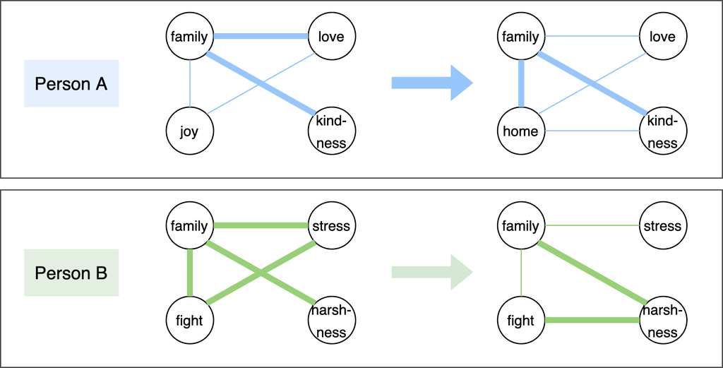

## Project phases

[figure not shown]

## New understanding

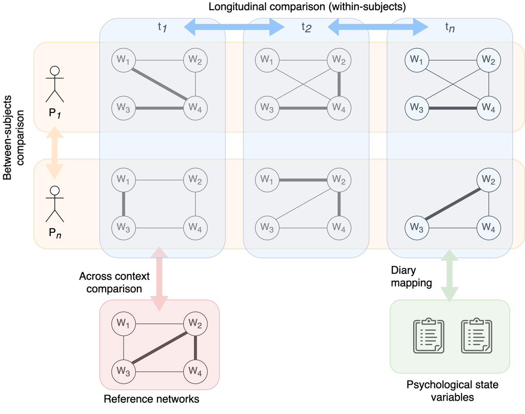

## So what?

1. fundamental aspect of how text data can be used across disciplines and problems
2. new interdisciplinary research line (NLP and psychological research)
3. asking (and answering) pressing questions, e.g.:
   - *How and when do some people develop radical ideas on online forums?*
   - *How can text data function as an early warning signal for mental health?*

## Thanks.

- bennett.kleinberg@tilburguniversity.edu
- https://bkleinberg.net/

These slides: https://bkleinberg.net/sub/veni_pres.html

## References

1.

Manning CD, Schütze H. Foundations of statistical natural language processing. Cambridge, Mass: MIT Press; 1999.

2.

Mikolov T, Sutskever I, Chen K, Corrado GS, Dean J. Distributed Representations of Words and Phrases and their Compositionality. Advances in Neural Information Processing Systems. 2013. pp. 3111–3119.

3.

Pennington J, Socher R, Manning C. Glove: Global Vectors for Word Representation. Proceedings of the 2014 Conference on Empirical Methods in Natural Language Processing (EMNLP). Doha, Qatar: Association for Computational Linguistics; 2014. pp. 1532–1543. doi:10.3115/v1/D14-1162

4.

Gentzkow M, Kelly B, Taddy M. Text as Data. Journal of Economic Literature. 2019;57: 535–574. doi:10.1257/jel.20181020

5.

Salganik MJ. Bit by bit: Social research in the digital age. Princeton, NJ: Princeton University Press; 2019.

6.

Boyd RL, Schwartz HA. Natural Language Analysis and the Psychology of Verbal Behavior: The Past, Present, and Future States of the Field. Journal of Language and Social Psychology. 2021;40: 21–41. doi:10.1177/0261927X20967028